# Airbnb data - from bookings to guests

Radoslaw Panczak

20 August, 2019

# 1 Airbnb data

## 1.1 `bedrooms` variable

### 1.1.1 Frequencies

```
##
## bedrooms <numeric>
## # total N=300931  valid N=296336  mean=1.84  sd=1.25
##
##   val    frq raw.prc valid.prc cum.prc
##     0  12820    4.26      4.33    4.33
##     1 141489   47.02     47.75   52.07
##     2  67949   22.58     22.93   75.00
##     3  43391   14.42     14.64   89.64
##     4  22035    7.32      7.44   97.08
##     5   6270    2.08      2.12   99.20
##     6   1493    0.50      0.50   99.70
##     7    433    0.14      0.15   99.85
##     8    154    0.05      0.05   99.90
##     9     67    0.02      0.02   99.92
```

[output cut: 23 more lines]

### 1.1.2 Zero `bedrooms`

12,820 properties have number of `bedrooms` listed as zero.

They are relatively clustered within few types of properties:

```
##
## property_type <character>
## # total N=12820  valid N=12820  mean=10.09  sd=11.41
##
##                             val  frq raw.prc valid.prc cum.prc
##                       Apartment 6804   53.07     53.07   53.07
##                           House 2452   19.13     19.13   72.20
##                     Guest suite  751    5.86      5.86   78.06
##                           Cabin  505    3.94      3.94   82.00
##                    Private room  332    2.59      2.59   84.59
##                        Bungalow  245    1.91      1.91   86.50
##               Bed and breakfast  231    1.80      1.80   88.30
##                         Cottage  169    1.32      1.32   89.62
##                           Place  156    1.22      1.22   90.83
##                        Campsite  146    1.14      1.14   91.97
##          Room in boutique hotel  139    1.08      1.08   93.06
##                       Camper/RV  122    0.95      0.95   94.01
##                           Tents  100    0.78      0.78   94.79
##                       Farm stay   92    0.72      0.72   95.51
##                          Hotels   91    0.71      0.71   96.22
##                           Other   87    0.68      0.68   96.90
##                      Tiny house   64    0.50      0.50   97.39
##                   Room in hotel   63    0.49      0.49   97.89
##                          Chalet   61    0.48      0.48   98.36
##                    Nature lodge   32    0.25      0.25   98.61
##                          Resort   28    0.22      0.22   98.83
##                            Barn   21    0.16      0.16   98.99
##                            Boat   19    0.15      0.15   99.14
##                       Treehouse   16    0.12      0.12   99.27
##                     Earth house   14    0.11      0.11   99.38
##                             Hut   14    0.11      0.11   99.49
##              Room in aparthotel   12    0.09      0.09   99.58
##                       Camper/rv   11    0.09      0.09   99.66
##              Serviced apartment    8    0.06      0.06   99.73
##                           Floor    5    0.04      0.04   99.77
##                          Castle    4    0.03      0.03   99.80
##                          In-law    4    0.03      0.03   99.83
##                           Train    4    0.03      0.03   99.86
##                       Houseboat    3    0.02      0.02   99.88
##                       Timeshare    3    0.02      0.02   99.91
##                 Casa particular    2    0.02      0.02   99.92
##          Casa particular (cuba)    2    0.02      0.02   99.94
##                          Island    2    0.02      0.02   99.95
##  Room in heritage hotel (india)    2    0.02      0.02   99.97
##                             Bus    1    0.01      0.01   99.98
##                            Cave    1    0.01      0.01   99.98
##                           Hotel    1    0.01      0.01   99.99
##                  Ryokan (japan)    1    0.01      0.01  100.00
##                            <NA>    0    0.00        NA      NA
```

These properties could be treated as having one room and occupancy will be capped by `Max_Guests` * `reservation_days`.

### 1.1.3 Missing `bedrooms`

4,595 properties have missing information on number of `bedrooms`.

109 of them have at least information on `max_guests`. Occupancy of these properties could be calculated as equal to some % of `max_guests`.

Occupancy of remaining properties with no info on `bedrooms` and `max_guests` could be set to some absolute minimum (one person?) or these properties could be removed.

### 1.1.4 Very large amount of `bedrooms`

There are several properties that have rather large number of rooms indicated in listings. Some of them are ‘legitimately’ large (for instance https://www.airbnb.com/rooms/2224983) and some are ‘artificially’ large - these are most likely propoerties rented on ‘per room’ basis showing their maximum capacity. Here is an example:

| property_id | property_type | listing_type | bedrooms | max_guests | reporting_month | number_of_reservations | reservation_days | adr_native | revenue_native |
| --- | --- | --- | --- | --- | --- | --- | --- | --- | --- |
| 19642549 | Guest suite | Private room | 50 | 16 | 2018-09-01 | 1 | 2 | 120 | 240 |
| 26147377 | Bed and breakfast | Private room | 50 | 3 | 2018-07-01 | 1 | 2 | 140 | 280 |
| 26147377 | Bed and breakfast | Private room | 50 | 3 | 2018-08-01 | 3 | 4 | 140 | 560 |
| 26147377 | Bed and breakfast | Private room | 50 | 3 | 2018-09-01 | 2 | 3 | 140 | 420 |
| 26147377 | Bed and breakfast | Private room | 50 | 3 | 2018-11-01 | 1 | 30 | 140 | 4200 |
| 26147377 | Bed and breakfast | Private room | 50 | 3 | 2018-12-01 | 2 | 3 | 140 | 420 |
| 26147377 | Bed and breakfast | Private room | 50 | 3 | 2019-02-01 | 1 | 1 | 140 | 140 |

Some examples: - https://www.airbnb.com/rooms/19642549 - https://www.airbnb.com/rooms/26147377 - https://www.airbnb.com/rooms/22311745

To handle such situations, 318 properties with **5 or more** `bedrooms` in category “Private room” of `Listing_Type` that had `ADR_(Native)` < 200 could have their number of rooms adjusted to (rounded) value of `Revenue_(Native)` divided by `ADR_(Native)`.

[output not shown]

## 1.2 Properties according to number of `bedrooms`

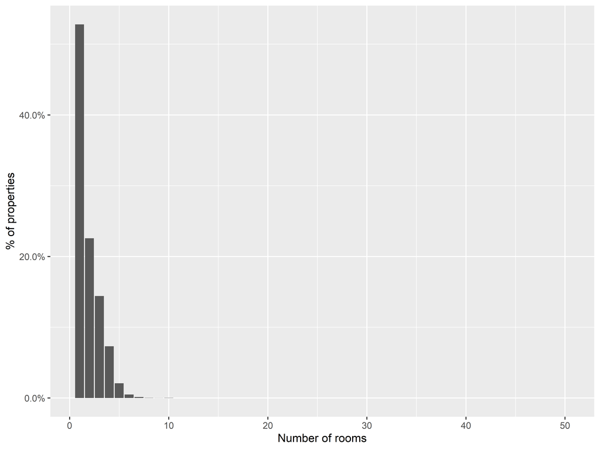

## 1.3 Mean `bedrooms` per state

```
## # A tibble: 8 x 4
##   STE_NAME16                    count  mean    sd
##   <chr>                         <int> <dbl> <dbl>
## 1 Australian Capital Territory   2379  1.43 0.817
## 2 New South Wales              124489  1.81 1.17
## 3 Northern Territory             1562  1.64 1.71
## 4 Queensland                    55852  1.90 1.18
## 5 South Australia               10840  2.04 1.28
## 6 Tasmania                       8540  1.96 1.54
## 7 Victoria                      75078  1.88 1.17
## 8 Western Australia             22191  1.97 1.30
```

## 1.4 Mean `max_guests` per state

```
## # A tibble: 8 x 4
##   STE_NAME16                    count  mean    sd
##   <chr>                         <int> <dbl> <dbl>
## 1 Australian Capital Territory   2379  2.94  1.94
## 2 New South Wales              124489  3.90  2.61
## 3 Northern Territory             1562  3.50  2.22
## 4 Queensland                    55852  4.15  2.69
## 5 South Australia               10840  4.56  2.92
## 6 Tasmania                       8540  4.51  2.85
## 7 Victoria                      75078  4.24  2.89
## 8 Western Australia             22191  4.18  2.71
```

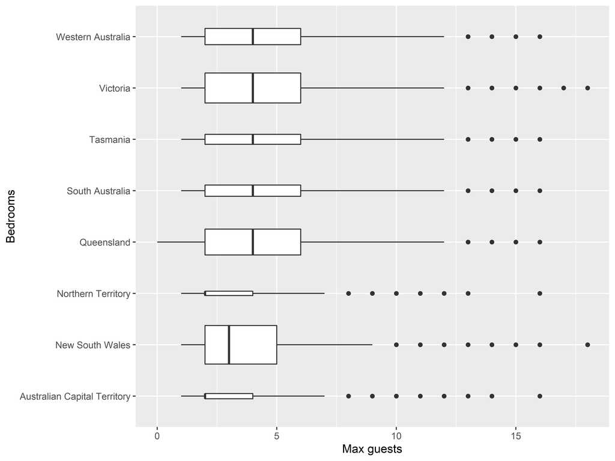

## 1.5 Number of properties and mean `bedrooms` per SA3

### 1.5.1 Map

[interactive chart not shown]

### 1.5.2 Treemap

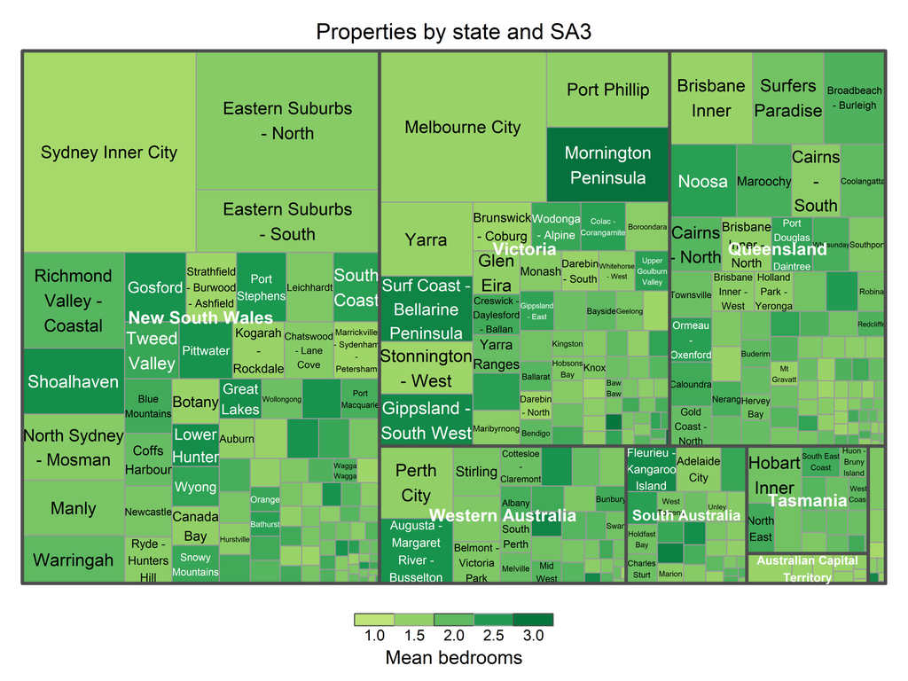

## 1.6 Relation between `bedrooms` and `max_guests`

### 1.6.1 Using original `bedrooms`

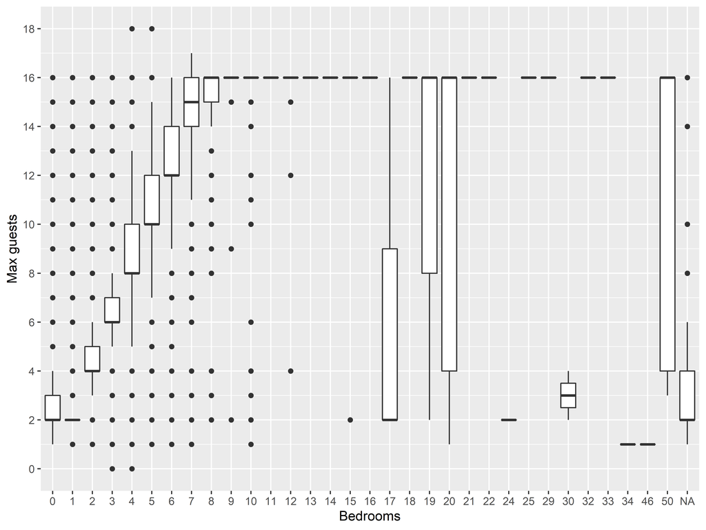

### 1.6.2 Using recalculated `bedrooms`

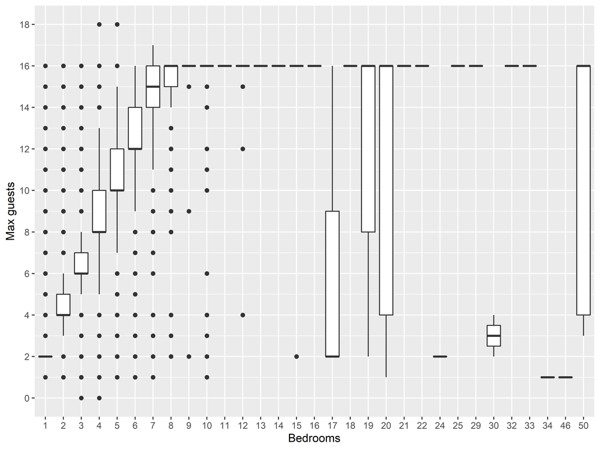

# 2 Occupancy rate

## 2.1 ABS Census 2016 data

`BEDD` variable representing *Number of bedrooms in Private Dwelling* was cross tabulated with `NPRD` variable *Number of Persons Usually Resident in Dwelling*.

Total number of people in each dwelling size was then divided by number of dwellings to derive ‘people per room’ figure. The drawback of this approach is that `NPRD` variable is capped at **Eight or more persons** most likely skewing calcualtions for larger units.

| BEDD | PP flat | PP room |
| --- | --- | --- |
| None | 1.50 | 1.50 |
| 1 bedroom | 1.38 | 1.38 |
| 2 bedrooms | 1.87 | 0.94 |
| 3 bedrooms | 2.50 | 0.83 |
| 4 bedrooms | 3.23 | 0.81 |
| 5 bedrooms | 3.90 | 0.78 |
| 6 bedrooms | 4.43 | 0.74 |
| 7 bedrooms | 4.80 | 0.69 |
| 8 bedrooms | 4.74 | 0.59 |
| 9 bedrooms | 4.31 | 0.48 |
| 10 bedrooms | 3.71 | 0.37 |
| 11 bedrooms | 2.37 | 0.22 |
| 12 bedrooms | 2.89 | 0.24 |
| 13 bedrooms | 2.96 | 0.23 |
| 14 bedrooms | 2.43 | 0.17 |

As an extension of this approach it is possible to also limit households included in this calculations. Here I took only households that belonged to categories:

- `DWTD` Dwelling Type: *Occupied private dwellings*
- `HOSD` Housing Suitability: *No bedrooms needed or spare*

| BEDD | PP flat | PP room |
| --- | --- | --- |
| None | 1.00 | 1.00 |
| 1 bedroom | 1.24 | 1.24 |
| 2 bedrooms | 2.57 | 1.28 |
| 3 bedrooms | 3.97 | 1.32 |
| 4 bedrooms | 5.19 | 1.30 |
| 5 bedrooms | 6.24 | 1.25 |
| 6 bedrooms | 7.13 | 1.19 |
| 7 bedrooms | 7.64 | 1.09 |
| 8 bedrooms | 8.00 | 1.00 |
| 9 bedrooms | 8.00 | 0.89 |
| 10 bedrooms | 8.00 | 0.80 |
| 11 bedrooms | 8.00 | 0.73 |

## 2.2 ABS tourist accomodation data

# 3 Conversion of rooms & bookings to guests nights occupied (GNO)